# 4-2 의사 결정 나무

# 4-2 의사 결정 나무(Decision Tree)

## 0. 데이터셋 소개

### Titanic

[Titanic](https://www.kaggle.com/competitions/titanic/data) 탑승객의 생존 유무를 담은 데이터셋 입니다.

| Data | Dictionary | Key |
| --- | --- | --- |
| PassengerId | Passenger Id | Index |
| Survived | Survival | 0 = No, 1 = Yes |
| Pclass | Ticket class | 1 = 1st, 2 = 2nd, 3 = 3rd |
| Name | Name |  |
| Sex | Sex |  |
| Age | Age in years |  |
| Sibsp | # of siblings / spouses aboard the Titanic |  |
| Parch | # of parents / children aboard the Titanic |  |
| Ticket | Ticket number |  |
| Fare | Passenger fare |  |
| Cabin | Cabin number |  |
| Embarked | Port of Embarkation | C = Cherbourg, Q = Queenstown, S = Southampton |

다양한 형식의 데이터를 가지고 있으며, 여러 가지 아이디어를 생각하고 시도할 만한 요소가 많게끔 기획된 데이터셋입니다.

```r
library(readr)
library(dplyr)
library(tidyverse)
library(fastDummies)
get_mode <- function(v) {
  tbl <- table(na.omit(v))
  names(tbl)[which.max(tbl)]
}

df_titanic <- read_csv('../data/titanic.csv', col_types = cols())
# Embarked는 최빈값으로 결측을 처리합니다.
df_titanic <- df_titanic %>%
  mutate(Embarked = ifelse(is.na(Embarked), get_mode(df_titanic$Embarked), Embarked))

# 범주형 변수 더미화 및 수치형 변수화
df_titanic <- df_titanic %>%
  mutate(Sex = ifelse(Sex == 'female', 1, 0)) %>%
  mutate(Pclass = as.factor(Pclass), Embarked = as.factor(Embarked)) %>%
  fastDummies::dummy_cols(select_columns = c('Pclass', 'Embarked'))

# 머신러닝에 사용할 변수들 정리
X_num <- c('Age', 'SibSp', 'Parch', 'Fare')
X_dum <- c('Pclass_1', 'Pclass_2', 'Pclass_3', 'Embarked_C', 'Embarked_Q', 'Embarked_S')
X_all <- c(X_num, X_dum)

# 결과 출력
print(X_all)
```

```
 [1] "Age"        "SibSp"      "Parch"      "Fare"       "Pclass_1"   "Pclass_2"   "Pclass_3"   "Embarked_C"
 [9] "Embarked_Q" "Embarked_S"
```

## 1. 종류 및 특징

| 모델명 | 특징 |
| --- | --- |
| ID3 (Iterative Dichotomiser 3) | 1. 분류에 사용됩니다. 2. 범주형 입력 데이터만 지원합니다. |
| C4.5 | 1. 연속형 입력 데이도 지원합니다. 2. 의사 결정 나무의 구조를 만든 후에 가지치기를 지원합니다. |
| CART (Classification and Regression Trees) | 1. 분류와 회귀 에 사용됩니다. |
| CHAID (Chi-squared Automatic Interaction Detector) | 1. 범주형 입력 데이터만 지원합니다. 2. 두 개 이상의 가지를 지닙니다. 3. 분류에서는 Chi2 검정통계량을 회귀에서는 ANOVA 검정통계량을 사용합니다. |

## 2. 구성 요소

| 요소명 | 설명 |
| --- | --- |
| 내부 노드(Internal Node) | 분기 조건과 결정 경로를 나타내는 가지(Branch)로 구성된 노드입니다. 이 중 최상위 노드를 루트 노드(Root Node)라고 합니다. |
| 가지(Branch) | 분기 조건에 해당하는 후속 노드와의 연결 관계를 나타내는 요소입니다. |
| 리프 노드(Leaf Node) | 가장 하위에 있는 노드로 더 이상 분기가 이루어지지 않고, 최종 예측 결과를 지니고 있는 노드 입니다. |

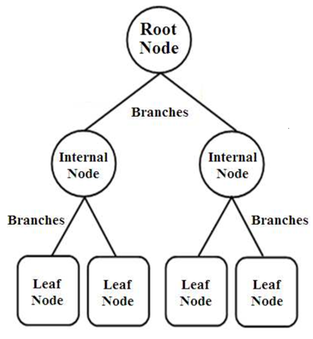

## 3.의사 결정 나무 학습

### 분기 조건의 선정

- 내부 노드(Internal Node)를 구성하는 분기 조건을 도출합니다.

#### 분기 조건의 표현

- 범주형일 경우 ‘변수명 = 범주’, 연속형일 경우 ‘변수명 < 분리점’
- scikit-learn의 Decision Tree를 기준으로 설명합니다.

> scikit-learn의 의사 결정 나무는 범주형은 가변수화를 하여 연속형, 범주형 동일하게 취급하고 ’변수명 <= 분리점’으로 조건을 나타냅니다.

#### 불순도

노드에 부여된 데이터의 대상 변수의 클래스가 혼재하는 정도를 나타냅니다.

##### 분류

1. 엔트로피(Entropy)

> $H(t) = -\sum_{i=1}^cp_ilog_2p_i$, t: 노드, $c$: 클래스의 수, $p_i$: i 클래스의 비율(출현 확률)

> $p_i$가 모두 동일할 경우 즉, 모든 확률이 $1/c$에 가까울 수록 엔트로피는 커집니다.
2. 지니 불순도(Gini impurity)

> $G(t) = \sum_{i=1}^cp_i(1 - p_i) = \sum_{i=1}^c\left(p_i - p_i^2\right)= 1 - \sum_{i=1}^cp_i^2$

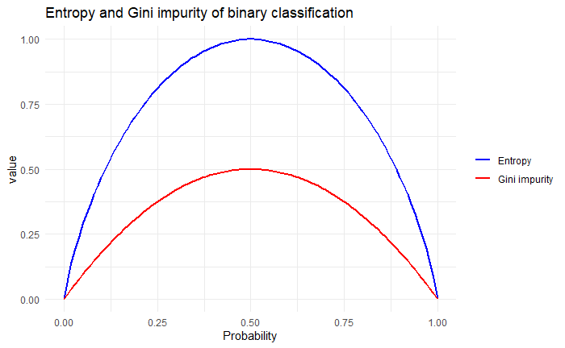

```r
library(ggplot2)

# 데이터 준비
x <- seq(0, 1, length.out = 101)
x2 <- x[2:100]

# 엔트로피 계산
entropy <- function(p) {
  ifelse(p == 0 | p == 1, 0, -p * log2(p) - (1 - p) * log2(1 - p))
}
e <- c(0, entropy(x2), 0)

# 지니 불순도 계산
gini_impurity <- 1 - (x^2 + (1 - x)^2)

# 데이터 프레임 생성
data <- data.frame(
  x = c(x, x),
  value = c(e, gini_impurity),
  measure = rep(c("Entropy", "Gini impurity"), each = length(x))
)

# 시각화
ggplot(data, aes(x = x, y = value, color = measure)) +
  geom_line(size = 1) +
  labs(
    x = "Probability",
    title = "Entropy and Gini impurity of binary classification"
  ) +
  scale_color_manual(values = c("Entropy" = "blue", "Gini impurity" = "red")) +
  theme_minimal() +
  theme(legend.title = element_blank())
```

##### 회귀

- 평균제곱오차(Mean Squared Error)

> $MSE(t) = \frac{1}{n}\sum_{i=1}^c\sum_{j=1}^{n_i}\left(y_{ij} - \bar{y_i}\right)^2$, $c$: 클래스의 수, $n_i$: i 클래스의 데이터수
- 평균절대오차(Mean Absolute Error)

> $MAE(t) = \frac{1}{n}\sum_{i=1}^c\sum_{j=1}^{n_i}|y_{ij} - median(y)_i|$, $c$: 클래스의 수, $n_i$: i 클래스의 데이터수

#### 불순도 감소량

데이터의 분기에 의해 감소된 불순도

▷ 부모 노드의 불순도에서 자식노드들의 불순도(데이터수에 대한 불순도의 가중합)를 뺀 값입니다.

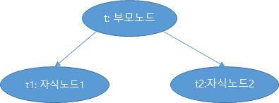

> $IG(t)$(t노드에 의해 감소된 불순도)$= imp(t) - \left(\frac{N(t_1)}{N(t)}imp(t1) + \frac{N(t_2)}{N(t)}imp(t2)\right)$

> $imp(t)$: t 노드의 불순도, $N(t)$: t 노드의 데이터수

특히, 엔트로피(Entropy)를 불순도로 사용했을 때 불순도 획득을 **정보 획득(Information Gain)**이라고 합니다.

#### Gini Index vs Entropy의 차이

Gini Impurity가 Entropy보다 스케일이 작기 때문에 자식노드의 데이터수의 가중치가 불순도 차감을 계산할 때 더 큰 영향을 주게 됩니다.

따라서 Gini Impurity로 불순도 차감을 계산할 때, 상대적으로 데이터의 수가 많은 노드들 위주로 분기가 이루어집니다.

**[Ex.1]**

df_titanic을 대상 변수 Survived에 대한 가변수 Parch 분기했을 때, Entropy로 불순도 차감을 계산합니다.

Parch 뿐만 아니라 일반적인 연속형 변수에서도 동작 가능하게 구현합니다.

```r
# 엔트로피 계산 함수
entropy <- function(x) {
  p <- x / sum(x)
  -sum(p * log2(ifelse(p > 0, p, 1)))
}

# 지니 불순도 계산 함수
gini <- function(x) {
  p <- x / sum(x)
  1 - sum(p ^ 2)
}
# Survived 열의 빈도 계산
survived_counts <- table(df_titanic$Survived)

# 불순도 계산
imp_func <- entropy # entropy를 불순도로 사용합니다.
#imp_func <- gini # 지니 불순도로 변경할 수 있습니다.

imp_t <- imp_func(survived_counts)
imp_t
```

```
[1] 0.9607079
```

**분기점 별 좌측 노드와 우측 노드의 엔트로피 구하기**

1. 변수 x의 모든 분기 지점을 구합니다.

> 등장하는 숫자 집합을 구합니다. ${a_1, a_2, ..., a_n}$ 모든 i에 대해서 $a_{i} < a_{i + 1}$ 입니다.

> 모든 i에 대해여, $a_i$와 $a_{i+1}$ 사이의 중간값으로 분기점을 만듭니다.: $b_{i} = \frac{a_i + a_{i+1}}{2}$
2. 분기점 별로 좌측 노드의 대상 클래스 빈도수를 구합니다.
3. 분기점 별로 좌측 노드의 클래스 빈도수를 이용하여, 좌/우측 노드의 불순도를 구합니다.

```r
library(dplyr)
library(tidyr)
# Parch에 등장하는 숫자에서 고유값을 구하고 이를 정렬합니다.
# Parch에 등장하는 숫자에서 고유값을 구하고 이를 정렬합니다.
u <- sort(unique(df_titanic$Parch))

# Parch에 등장하는 숫자에서 만들 수 있는 분기점을 구합니다.
b <- c(-Inf, (u[-1] + u[-length(u)]) / 2, Inf)
# Parch를 분기점으로 구간화하고, Survived와의 교차 테이블을 만듭니다.
df_titanic$Parch_cut <- cut(df_titanic$Parch, breaks = b, right = TRUE)

# 교차 테이블을 계산합니다.
df_cnt <- table(df_titanic$Parch_cut, df_titanic$Survived)
df_cnt[, "0"] <- cumsum(df_cnt[, "0"])
df_cnt[, "1"] <- cumsum(df_cnt[, "1"])
rownames(df_cnt) <- paste0("Parch <= ", b[-1])

df_cnt
```

```
                 0   1
  Parch <= 0.5 445 233
  Parch <= 1.5 498 298
  Parch <= 2.5 538 338
  Parch <= 3.5 540 341
  Parch <= 4.5 544 341
  Parch <= 5.5 548 342
  Parch <= Inf 549 342
```

**[참고]**

연속형 변수의 최적의 분기점을 찾기 위해서는 최악의 경우에는 데이터의 수만큼 선형 탐색을 해야 합니다.

백분위 기반으로 연속형 변수를 구간화하여 분기점 찾는 속도를 효율화하는 방법이 널리 쓰입니다.

https://scikit-learn.org/stable/modules/generated/sklearn.ensemble.HistGradientBoostingRegressor.html

```r
# 불순도 함수 선택
imp_func <- entropy # 또는 gini

# 좌측 노드의 불순도와 가중치 계산
result <- apply(df_cnt, 1, function(x) {
  imp <- imp_func(x)
  weight <- sum(x) / nrow(df_titanic)
  c(imp, weight)
})

# 결과를 데이터 프레임으로 변환
result_df <- as.data.frame(t(result))
colnames(result_df) <- c("imp", "weight")
result_df
```

|  | imp | weight |
| --- | --- | --- |
| Parch <= 0.5 | 0.9282760 | 0.7609428 |
| Parch <= 1.5 | 0.9539699 | 0.8933782 |
| Parch <= 2.5 | 0.9620656 | 0.9831650 |
| Parch <= 3.5 | 0.9628761 | 0.9887767 |
| Parch <= 4.5 | 0.9617066 | 0.9932660 |
| Parch <= 5.5 | 0.9610018 | 0.9988777 |
| Parch <= Inf | 0.9607079 | 1.0000000 |

```r
# 우측 노드의 빈도수 계산
df_cnt_right <- df_cnt
df_cnt_right[, "0"] = survived_counts["0"] - df_cnt_right[, "0"]
df_cnt_right[, "1"] = survived_counts["1"] - df_cnt_right[, "1"]

# 좌측 노드의 불순도와 가중치 계산
result <- apply(df_cnt_right, 1, function(x) {
  imp <- imp_func(x)
  weight <- sum(x) / nrow(df_titanic)
  c(imp, weight)
})

# 결과를 데이터 프레임으로 변환
result_df <- as.data.frame(t(result))
colnames(result_df) <- c("imp", "weight")
result_df
```

|  | imp | weight |
| --- | --- | --- |
| Parch <= 0.5 | 0.9996025 | 0.239057239 |
| Parch <= 1.5 | 0.9960800 | 0.106621773 |
| Parch <= 2.5 | 0.8366407 | 0.016835017 |
| Parch <= 3.5 | 0.4689956 | 0.011223345 |
| Parch <= 4.5 | 0.6500224 | 0.006734007 |
| Parch <= 5.5 | 0.0000000 | 0.001122334 |
| Parch <= Inf | NA | 0.000000000 |

```r
# 좌측 노드와 우측 노드의 불순도의 가중합을 계산
n <- nrow(df_titanic)
df_imp <- apply(df_cnt, 1, function(x) {
  imp_func(x / sum(x)) * sum(x) / n
}) + apply(df_cnt_right, 1, function(x) {
  imp_func(x / sum(x)) * sum(x) / n
})

# 결과 출력
print(df_imp)
```

```
Parch <= 0.5 Parch <= 1.5 Parch <= 2.5 Parch <= 3.5 Parch <= 4.5 Parch <= 5.5 Parch <= Inf
   0.9453271    0.9584597    0.9599541    0.9573331    0.9596077    0.9599233           NA
```

```r
imp_t - df_imp
```

```
Parch <= 0.5 Parch <= 1.5 Parch <= 2.5 Parch <= 3.5 Parch <= 4.5 Parch <= 5.5 Parch <= Inf
0.0153807545 0.0022481759 0.0007538336 0.0033747573 0.0011001568 0.0007846511           NA
```

### 나무의 성장 방법

- 레벨기준(Level(Depth)-Wise)

나무의 레벨을 기준으로 나무를 성장 시킵니다.

- 성능기준(Best-First, Leaf-Wise)

나무의 불순도 차감을 기준으로 나무를 성장 시킵니다.

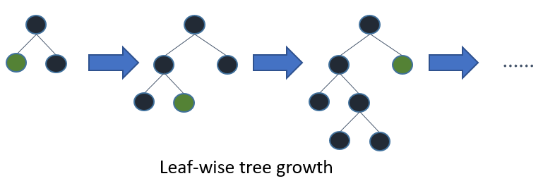

※ 이미지 출처: https://lightgbm.readthedocs.io/en/latest/Features.html

**장단점 비교**

| 방법 | 장점 | 단점 |
| --- | --- | --- |
| Level-wise | 구조가 단순하여 해석이 쉽습니다. 계산 비용이 Leaf-wise에 비해 낮습니다. 각 레벨에서 독립적으로 분기를 하므로 병렬화에 용이합니다. | Leaf-wise에 비해 비효율적인 분할을 지닐 가능성이 높습니다. |
| Leaf-wise | 효과가 높은 것을 우선 분기하여 최적의 구조를 찾을 가능성이 높습니다. | 계산 비용이 Level-wise에 비해 높습니다. 과적합 가능성이 Level-wise에 비해 높습니다. 최선의 노드를 선택 후에 분기를 위한 연산이 일어나는 의존적 구조라 병렬화가 어렵습니다. |

## 4. 가지치기(Pruning)

의사 결정 나무는 데이터에 맞추어 가설 공간을 키워 갈수 있는 구조입니다.

크기의 제한이 없다면 높은 모델의 복잡도로 인해 지나치게 높은 분산으로 인한 과적합이 발생합니다.

의사 결정 나무 학습이전에 크기의 제한을 두는 사전가지치기(Pre-pruning)과

학습후에 크기를 줄이는 사후 가지치기(Post-pruning)가 있습니다.

**[Ex.3]**

max_depth 에 따라 학습과 평가의 성능이 어떻게 변하는지 확인합니다.

입력 변수는 X_all 리스트에 있는 변수이고, 대상 변수는 Survived 입니다.

성능 측정 지표는 정확도(Accuracy) 입니다.

```
max_depths = np.arange(2, 13)
```

```r
library(rpart)

# 학습 및 테스트 데이터 분할
set.seed(123)
trainIndex <- createDataPartition(df_titanic$Survived, p = 0.8,
                                  list = FALSE,
                                  times = 1)

df_train <- df_titanic[trainIndex, c(X_all, 'Survived')]
df_test <- df_titanic[-trainIndex, c(X_all, 'Survived')]


# 결정 트리 모델 학습 및 정확도 계산
max_depths <- 2:12
acc_train <- c()
acc_test <- c()

for (max_depth in max_depths) {
  clf_dt <- rpart(Survived ~ ., data = df_train, method = "class", control = rpart.control(maxdepth = max_depth))

  pred_train <- predict(clf_dt, newdata = df_train, type = "class")
  pred_test <- predict(clf_dt, newdata = df_test, type = "class")

  acc_train <- c(acc_train, mean(pred_train == df_train$Survived))
  acc_test <- c(acc_test, mean(pred_test == df_test$Survived))
}

# 결과 출력
results <- data.frame(
  max_depth = max_depths,
  acc_train = acc_train,
  acc_test = acc_test
)
print(results)
```

| max_depth | acc_train | acc_test |
| --- | --- | --- |
| 2 | 0.6970547 | 0.7415730 |
| 3 | 0.7082749 | 0.7415730 |
| 4 | 0.7082749 | 0.7415730 |
| 5 | 0.7082749 | 0.7415730 |
| 6 | 0.7223001 | 0.7359551 |
| 7 | 0.7223001 | 0.7359551 |
| 8 | 0.7307153 | 0.7471910 |
| 9 | 0.7307153 | 0.7471910 |
| 10 | 0.7405330 | 0.7528090 |
| 11 | 0.7405330 | 0.7528090 |

[output cut: 1 more lines]

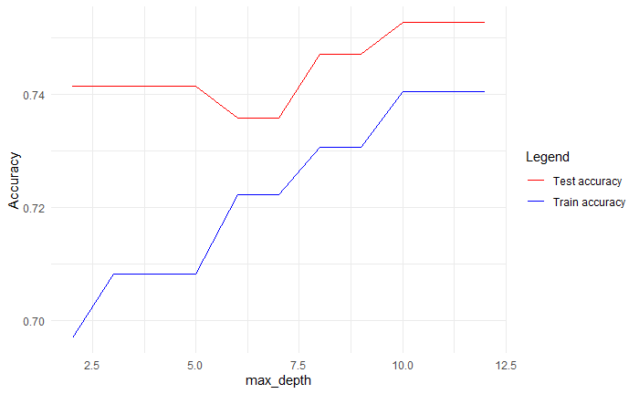

```r
# 결과 시각화
ggplot(results, aes(x = max_depth)) +
  geom_line(aes(y = acc_train, color = "Train accuracy")) +
  geom_line(aes(y = acc_test, color = "Test accuracy")) +
  labs(x = "max_depth", y = "Accuracy") +
  scale_color_manual(name = "Legend", values = c("Train accuracy" = "blue", "Test accuracy" = "red")) +
  theme_minimal()
```

## 의사 결정 나무의 장단점

### 장점

- 데이터의 전처리의 필요성이 적습니다.
- 이상치에 상대적으로 덜 민감합니다.
- 직관적인 해석을 할 수 있는 형태를 보입니다.
- 모델에 가정을 두고 있지 않으므로, 다양한 문제에 적용할 수 있습니다.

### 단점

- 과적합에 대응하기 위한 모델의 최적화가 상대적으로 많이 필요합니다.
- 데이터의 작은 변화에도 모델의 출력 결과가 크게 변하기 쉽습니다.